# Intro to R: Day 1 Part 2

## Data Frames and Subsetting

Part 2 of the workshop. Start at ‘Realsitic Example’ https://swcarpentry.github.io/r-novice-gapminder/05-data-structures-part2/index.html#realistic-example

We are going to use the datafile that you downloaded into your project data folder.

### There are at least three different ways to read in data:

1. read the file from your data folder

```r
gapminder <- read.csv("data/gapminder_data.csv", stringsAsFactors = TRUE)
```

2. download the file in-code and then read in

```r
download.file("https://raw.githubusercontent.com/swcarpentry/r-novice-gapminder/main/data/gapminder_data.csv", destfile = "data/gapminder_data.csv")

gapminder <- read.csv("data/gapminder_data.csv", stringsAsFactors = TRUE)
```

3. read directly from the internet

```r
gapminder <- read.csv("https://raw.githubusercontent.com/swcarpentry/r-novice-gapminder/main/data/gapminder_data.csv", stringsAsFactors = TRUE)
```

Lasty, if you have a file type you’re not sure about (SAS, SPSS, etc) you can use the ’Import Dataset’from the RStudio interface.

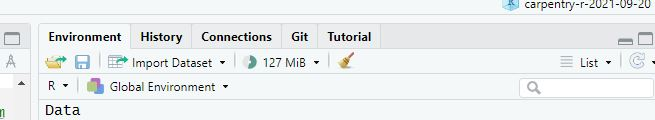

Import Dataset interface

## Examine your dataset using the str() and summary() functions

**str()** or allows you to get a compact look at the layout or *structure* of your dataset

```r
str(gapminder)
```

```
## 'data.frame':    1704 obs. of  6 variables:
##  $ country  : Factor w/ 142 levels "Afghanistan",..: 1 1 1 1 1 1 1 1 1 1 ...
##  $ year     : int  1952 1957 1962 1967 1972 1977 1982 1987 1992 1997 ...
##  $ pop      : num  8425333 9240934 10267083 11537966 13079460 ...
##  $ continent: Factor w/ 5 levels "Africa","Americas",..: 3 3 3 3 3 3 3 3 3 3 ...
##  $ lifeExp  : num  28.8 30.3 32 34 36.1 ...
##  $ gdpPercap: num  779 821 853 836 740 ...
```

**summary(*object*)** is another way to examine your dataset. It gives you numeric, tabular, or descriptive summary of each column.

```r
summary(gapminder)
```

```
##         country          year           pop               continent
##  Afghanistan:  12   Min.   :1952   Min.   :6.001e+04   Africa  :624
##  Albania    :  12   1st Qu.:1966   1st Qu.:2.794e+06   Americas:300
##  Algeria    :  12   Median :1980   Median :7.024e+06   Asia    :396
##  Angola     :  12   Mean   :1980   Mean   :2.960e+07   Europe  :360
##  Argentina  :  12   3rd Qu.:1993   3rd Qu.:1.959e+07   Oceania : 24
##  Australia  :  12   Max.   :2007   Max.   :1.319e+09
##  (Other)    :1632
##     lifeExp        gdpPercap
##  Min.   :23.60   Min.   :   241.2
##  1st Qu.:48.20   1st Qu.:  1202.1
##  Median :60.71   Median :  3531.8
##  Mean   :59.47   Mean   :  7215.3
##  3rd Qu.:70.85   3rd Qu.:  9325.5
##  Max.   :82.60   Max.   :113523.1
##
```

You can also summarize a column:

```r
summary(gapminder$country)
```

```
##              Afghanistan                  Albania                  Algeria
##                       12                       12                       12
##                   Angola                Argentina                Australia
##                       12                       12                       12
##                  Austria                  Bahrain               Bangladesh
##                       12                       12                       12
##                  Belgium                    Benin                  Bolivia
##                       12                       12                       12
##   Bosnia and Herzegovina                 Botswana                   Brazil
##                       12                       12                       12
##                 Bulgaria             Burkina Faso                  Burundi
##                       12                       12                       12
##                 Cambodia                 Cameroon                   Canada
##                       12                       12                       12
## Central African Republic                     Chad                    Chile
##                       12                       12                       12
##                    China                 Colombia                  Comoros
##                       12                       12                       12
##          Congo Dem. Rep.               Congo Rep.               Costa Rica
##                       12                       12                       12
##            Cote d'Ivoire                  Croatia                     Cuba
##                       12                       12                       12
##           Czech Republic                  Denmark                 Djibouti
##                       12                       12                       12
##       Dominican Republic                  Ecuador                    Egypt
##                       12                       12                       12
##              El Salvador        Equatorial Guinea                  Eritrea
##                       12                       12                       12
##                 Ethiopia                  Finland                   France
##                       12                       12                       12
##                    Gabon                   Gambia                  Germany
##                       12                       12                       12
##                    Ghana                   Greece                Guatemala
##                       12                       12                       12
##                   Guinea            Guinea-Bissau                    Haiti
##                       12                       12                       12
##                 Honduras          Hong Kong China                  Hungary
##                       12                       12                       12
##                  Iceland                    India                Indonesia
##                       12                       12                       12
```

[output cut: 13 more lines]

```
##                       12                       12                       12
##                Mauritius                   Mexico                 Mongolia
##                       12                       12                       12
##               Montenegro                  Morocco               Mozambique
##                       12                       12                       12
##                  Myanmar                  Namibia                    Nepal
##                       12                       12                       12
##              Netherlands              New Zealand                Nicaragua
##                       12                       12                       12
##                    Niger                  Nigeria                   Norway
##                       12                       12                       12
##                     Oman                 Pakistan                   Panama
##                       12                       12                       12
##                  (Other)
##                      516
```

### Other functions you can use to examine data:

(demo) typeof(object$colum)

Use **str()** on a colum: **str(country$year)**

We can also interrogate the data frame for information about its dimensions; remembering that `str(gapminder)` said there were 1704 observations of 6 variables in gapminder, what do you think the following will produce, and why?

```r
length(gapminder)
```

```
## [1] 6
```

### Get the number of Rows and Columns

**nrow(gapminder)**

**ncol(gapminder)**

**dim(gapminder)** to get both rows and colums

### Display the beginning or end of a dataset

Recall from the shell lesson the head() and tail() functions

head(gapminder)

tail(gapminder)

## Subsetting your data

### Subsetting Operatiors

Why subset?

**Elements can be accessed by their indices**

Try this: essentially get me the nth element

```r
head(gapminder[1])
```

```
##       country
## 1 Afghanistan
## 2 Afghanistan
## 3 Afghanistan
## 4 Afghanistan
## 5 Afghanistan
## 6 Afghanistan
```

1st column

And then:

```r
head(gapminder[1,1])
```

```
## [1] Afghanistan
## 142 Levels: Afghanistan Albania Algeria Angola Argentina Australia ... Zimbabwe
```

1st column, first element

**Multiple elements: accessing two or more columns**

```r
head(gapminder[c(1, 3)])
```

```
##       country      pop
## 1 Afghanistan  8425333
## 2 Afghanistan  9240934
## 3 Afghanistan 10267083
## 4 Afghanistan 11537966
## 5 Afghanistan 13079460
## 6 Afghanistan 14880372
```

## Slice all of a specific row

```r
gapminder[3, ]
```

```
##       country year      pop continent lifeExp gdpPercap
## 3 Afghanistan 1962 10267083      Asia  31.997  853.1007
```

##Slice all of a specific column

```r
head(gapminder[ , 3])
```

```
## [1]  8425333  9240934 10267083 11537966 13079460 14880372
```

**Slice to access multiple consecutive columns**

```r
head(gapminder[1:4])
```

```
##       country year      pop continent
## 1 Afghanistan 1952  8425333      Asia
## 2 Afghanistan 1957  9240934      Asia
## 3 Afghanistan 1962 10267083      Asia
## 4 Afghanistan 1967 11537966      Asia
## 5 Afghanistan 1972 13079460      Asia
## 6 Afghanistan 1977 14880372      Asia
```

**Question: what happens if you ask for an index that doesn’t exist?**

**how would you check to see what the size of the dataset is?**

dim(gapminder)

###Subsetting by name: create a subset of country, population and gdpPercap data

```r
head(gapminder[c("country", "pop", "gdpPercap")])
```

```
##       country      pop gdpPercap
## 1 Afghanistan  8425333  779.4453
## 2 Afghanistan  9240934  820.8530
## 3 Afghanistan 10267083  853.1007
## 4 Afghanistan 11537966  836.1971
## 5 Afghanistan 13079460  739.9811
## 6 Afghanistan 14880372  786.1134
```

###Factor subsetting: subset by category (ie. race, sex, age, etc)

There isn’t a column like this in gapminder but you may run into this with datasets that have demographic data.

Another way to look at a section of the dataset is:

```r
gapminder[1:15,]
```

```
##        country year      pop continent lifeExp gdpPercap
## 1  Afghanistan 1952  8425333      Asia  28.801  779.4453
## 2  Afghanistan 1957  9240934      Asia  30.332  820.8530
## 3  Afghanistan 1962 10267083      Asia  31.997  853.1007
## 4  Afghanistan 1967 11537966      Asia  34.020  836.1971
## 5  Afghanistan 1972 13079460      Asia  36.088  739.9811
## 6  Afghanistan 1977 14880372      Asia  38.438  786.1134
## 7  Afghanistan 1982 12881816      Asia  39.854  978.0114
## 8  Afghanistan 1987 13867957      Asia  40.822  852.3959
## 9  Afghanistan 1992 16317921      Asia  41.674  649.3414
## 10 Afghanistan 1997 22227415      Asia  41.763  635.3414
## 11 Afghanistan 2002 25268405      Asia  42.129  726.7341
## 12 Afghanistan 2007 31889923      Asia  43.828  974.5803
## 13     Albania 1952  1282697    Europe  55.230 1601.0561
## 14     Albania 1957  1476505    Europe  59.280 1942.2842
## 15     Albania 1962  1728137    Europe  64.820 2312.8890
```

Explain the syntax example

gapminder[1:3, 5]

gapminder[1:3, ]

##Other ways to extract based on values

```r
gapminder[gapminder$lifeExp > 80, ]
```

```
##              country year       pop continent lifeExp gdpPercap
## 71         Australia 2002  19546792   Oceania  80.370  30687.75
## 72         Australia 2007  20434176   Oceania  81.235  34435.37
## 252           Canada 2007  33390141  Americas  80.653  36319.24
## 540           France 2007  61083916    Europe  80.657  30470.02
## 671  Hong Kong China 2002   6762476      Asia  81.495  30209.02
## 672  Hong Kong China 2007   6980412      Asia  82.208  39724.98
## 695          Iceland 2002    288030    Europe  80.500  31163.20
## 696          Iceland 2007    301931    Europe  81.757  36180.79
## 768           Israel 2007   6426679      Asia  80.745  25523.28
## 779            Italy 2002  57926999    Europe  80.240  27968.10
## 780            Italy 2007  58147733    Europe  80.546  28569.72
## 802            Japan 1997 125956499      Asia  80.690  28816.58
## 803            Japan 2002 127065841      Asia  82.000  28604.59
## 804            Japan 2007 127467972      Asia  82.603  31656.07
## 1104     New Zealand 2007   4115771   Oceania  80.204  25185.01
## 1152          Norway 2007   4627926    Europe  80.196  49357.19
## 1428           Spain 2007  40448191    Europe  80.941  28821.06
## 1475          Sweden 2002   8954175    Europe  80.040  29341.63
## 1476          Sweden 2007   9031088    Europe  80.884  33859.75
## 1487     Switzerland 2002   7361757    Europe  80.620  34480.96
## 1488     Switzerland 2007   7554661    Europe  81.701  37506.42
```

```r
gapminder[gapminder$lifeExp > 80, 1:5]
```

```
##              country year       pop continent lifeExp
## 71         Australia 2002  19546792   Oceania  80.370
## 72         Australia 2007  20434176   Oceania  81.235
## 252           Canada 2007  33390141  Americas  80.653
## 540           France 2007  61083916    Europe  80.657
## 671  Hong Kong China 2002   6762476      Asia  81.495
## 672  Hong Kong China 2007   6980412      Asia  82.208
## 695          Iceland 2002    288030    Europe  80.500
## 696          Iceland 2007    301931    Europe  81.757
## 768           Israel 2007   6426679      Asia  80.745
## 779            Italy 2002  57926999    Europe  80.240
## 780            Italy 2007  58147733    Europe  80.546
## 802            Japan 1997 125956499      Asia  80.690
## 803            Japan 2002 127065841      Asia  82.000
## 804            Japan 2007 127467972      Asia  82.603
## 1104     New Zealand 2007   4115771   Oceania  80.204
## 1152          Norway 2007   4627926    Europe  80.196
## 1428           Spain 2007  40448191    Europe  80.941
## 1475          Sweden 2002   8954175    Europe  80.040
## 1476          Sweden 2007   9031088    Europe  80.884
## 1487     Switzerland 2002   7361757    Europe  80.620
## 1488     Switzerland 2007   7554661    Europe  81.701
```

or to get all the columns

```r
gapminder[gapminder$lifeExp > 80,]
```

```
##              country year       pop continent lifeExp gdpPercap
## 71         Australia 2002  19546792   Oceania  80.370  30687.75
## 72         Australia 2007  20434176   Oceania  81.235  34435.37
## 252           Canada 2007  33390141  Americas  80.653  36319.24
## 540           France 2007  61083916    Europe  80.657  30470.02
## 671  Hong Kong China 2002   6762476      Asia  81.495  30209.02
## 672  Hong Kong China 2007   6980412      Asia  82.208  39724.98
## 695          Iceland 2002    288030    Europe  80.500  31163.20
## 696          Iceland 2007    301931    Europe  81.757  36180.79
## 768           Israel 2007   6426679      Asia  80.745  25523.28
## 779            Italy 2002  57926999    Europe  80.240  27968.10
## 780            Italy 2007  58147733    Europe  80.546  28569.72
## 802            Japan 1997 125956499      Asia  80.690  28816.58
## 803            Japan 2002 127065841      Asia  82.000  28604.59
## 804            Japan 2007 127467972      Asia  82.603  31656.07
## 1104     New Zealand 2007   4115771   Oceania  80.204  25185.01
## 1152          Norway 2007   4627926    Europe  80.196  49357.19
## 1428           Spain 2007  40448191    Europe  80.941  28821.06
## 1475          Sweden 2002   8954175    Europe  80.040  29341.63
## 1476          Sweden 2007   9031088    Europe  80.884  33859.75
## 1487     Switzerland 2002   7361757    Europe  80.620  34480.96
## 1488     Switzerland 2007   7554661    Europe  81.701  37506.42
```

##Extract specific rows

```r
gapminder[c(1:9, 19:23),]
```

```
##        country year      pop continent lifeExp gdpPercap
## 1  Afghanistan 1952  8425333      Asia  28.801  779.4453
## 2  Afghanistan 1957  9240934      Asia  30.332  820.8530
## 3  Afghanistan 1962 10267083      Asia  31.997  853.1007
## 4  Afghanistan 1967 11537966      Asia  34.020  836.1971
## 5  Afghanistan 1972 13079460      Asia  36.088  739.9811
## 6  Afghanistan 1977 14880372      Asia  38.438  786.1134
## 7  Afghanistan 1982 12881816      Asia  39.854  978.0114
## 8  Afghanistan 1987 13867957      Asia  40.822  852.3959
## 9  Afghanistan 1992 16317921      Asia  41.674  649.3414
## 19     Albania 1982  2780097    Europe  70.420 3630.8807
## 20     Albania 1987  3075321    Europe  72.000 3738.9327
## 21     Albania 1992  3326498    Europe  71.581 2497.4379
## 22     Albania 1997  3428038    Europe  72.950 3193.0546
## 23     Albania 2002  3508512    Europe  75.651 4604.2117
```

### Subset by logical operators:

```r
gapminder[gapminder$year == 1957,]
```

```
##                       country year       pop continent  lifeExp   gdpPercap
## 2                 Afghanistan 1957   9240934      Asia 30.33200    820.8530
## 14                    Albania 1957   1476505    Europe 59.28000   1942.2842
## 26                    Algeria 1957  10270856    Africa 45.68500   3013.9760
## 38                     Angola 1957   4561361    Africa 31.99900   3827.9405
## 50                  Argentina 1957  19610538  Americas 64.39900   6856.8562
## 62                  Australia 1957   9712569   Oceania 70.33000  10949.6496
## 74                    Austria 1957   6965860    Europe 67.48000   8842.5980
## 86                    Bahrain 1957    138655      Asia 53.83200  11635.7995
## 98                 Bangladesh 1957  51365468      Asia 39.34800    661.6375
## 110                   Belgium 1957   8989111    Europe 69.24000   9714.9606
## 122                     Benin 1957   1925173    Africa 40.35800    959.6011
## 134                   Bolivia 1957   3211738  Americas 41.89000   2127.6863
## 146    Bosnia and Herzegovina 1957   3076000    Europe 58.45000   1353.9892
## 158                  Botswana 1957    474639    Africa 49.61800    918.2325
```

[output cut: 128 more lines]

### AND OR

```r
gapminder[gapminder$year > 1957 | gapminder$year < 1987, ]
```

```
##                       country year        pop continent  lifeExp   gdpPercap
## 1                 Afghanistan 1952    8425333      Asia 28.80100    779.4453
## 2                 Afghanistan 1957    9240934      Asia 30.33200    820.8530
## 3                 Afghanistan 1962   10267083      Asia 31.99700    853.1007
## 4                 Afghanistan 1967   11537966      Asia 34.02000    836.1971
## 5                 Afghanistan 1972   13079460      Asia 36.08800    739.9811
## 6                 Afghanistan 1977   14880372      Asia 38.43800    786.1134
## 7                 Afghanistan 1982   12881816      Asia 39.85400    978.0114
## 8                 Afghanistan 1987   13867957      Asia 40.82200    852.3959
## 9                 Afghanistan 1992   16317921      Asia 41.67400    649.3414
## 10                Afghanistan 1997   22227415      Asia 41.76300    635.3414
## 11                Afghanistan 2002   25268405      Asia 42.12900    726.7341
## 12                Afghanistan 2007   31889923      Asia 43.82800    974.5803
## 13                    Albania 1952    1282697    Europe 55.23000   1601.0561
## 14                    Albania 1957    1476505    Europe 59.28000   1942.2842
```

[output cut: 1690 more lines]

or

```r
gapminder[gapminder$year %in% c(1957, 1987),]
```

```
##                       country year        pop continent  lifeExp   gdpPercap
## 2                 Afghanistan 1957    9240934      Asia 30.33200    820.8530
## 8                 Afghanistan 1987   13867957      Asia 40.82200    852.3959
## 14                    Albania 1957    1476505    Europe 59.28000   1942.2842
## 20                    Albania 1987    3075321    Europe 72.00000   3738.9327
## 26                    Algeria 1957   10270856    Africa 45.68500   3013.9760
## 32                    Algeria 1987   23254956    Africa 65.79900   5681.3585
## 38                     Angola 1957    4561361    Africa 31.99900   3827.9405
## 44                     Angola 1987    7874230    Africa 39.90600   2430.2083
## 50                  Argentina 1957   19610538  Americas 64.39900   6856.8562
## 56                  Argentina 1987   31620918  Americas 70.77400   9139.6714
## 62                  Australia 1957    9712569   Oceania 70.33000  10949.6496
## 68                  Australia 1987   16257249   Oceania 76.32000  21888.8890
## 74                    Austria 1957    6965860    Europe 67.48000   8842.5980
## 80                    Austria 1987    7578903    Europe 74.94000  23687.8261
```

[output cut: 270 more lines]

```r
gapminder[gapminder$year > 1957 | gapminder$year < 1987 | gapminder$lifeExp < 60 , ]
```

```
##                       country year        pop continent  lifeExp   gdpPercap
## 1                 Afghanistan 1952    8425333      Asia 28.80100    779.4453
## 2                 Afghanistan 1957    9240934      Asia 30.33200    820.8530
## 3                 Afghanistan 1962   10267083      Asia 31.99700    853.1007
## 4                 Afghanistan 1967   11537966      Asia 34.02000    836.1971
## 5                 Afghanistan 1972   13079460      Asia 36.08800    739.9811
## 6                 Afghanistan 1977   14880372      Asia 38.43800    786.1134
## 7                 Afghanistan 1982   12881816      Asia 39.85400    978.0114
## 8                 Afghanistan 1987   13867957      Asia 40.82200    852.3959
## 9                 Afghanistan 1992   16317921      Asia 41.67400    649.3414
## 10                Afghanistan 1997   22227415      Asia 41.76300    635.3414
## 11                Afghanistan 2002   25268405      Asia 42.12900    726.7341
## 12                Afghanistan 2007   31889923      Asia 43.82800    974.5803
## 13                    Albania 1952    1282697    Europe 55.23000   1601.0561
## 14                    Albania 1957    1476505    Europe 59.28000   1942.2842
```

[output cut: 1690 more lines]

##Right now these subset only exists in memory, save as a separate frame

```r
mySlice <- gapminder[gapminder$year > 1957 | gapminder$year < 1987 | gapminder$lifeExp < 60 , ]
```

### Challange: get in groups (or individually) and create a subset of the gapminder data

This will be used for next days plotting.